# Regression Model for [PROJECT NAME] Using Python and AutoKeras Version 3

### 1.d) Data Cleaning

```python
# Standardize the class column to the name of targetVar if required
# df_dataset_import = df_dataset_import.rename(columns={'old_name': 'targetVar'})

# Dropping features
# df_dataset_import.drop(columns=['column1','column2','column3'], inplace=True)

# Impute missing values
# df_dataset_import['col_name'].fillna('someValue', inplace=True)
# df_dataset_import['col_name'].fillna(value=df_dataset_import['col_name'].median(), inplace=True)

# Convert columns from one data type to another
# df_dataset_import.column_name = Xy_original.column_name.astype('int')
# df_dataset_import.column_name = Xy_original.column_name.astype('category')
df_dataset_import.CHAS = df_dataset_import.CHAS.astype('float')
df_dataset_import.RAD = df_dataset_import.RAD.astype('float')

# Convert features with 1/0 levels into categorical feature of Y/N
# def reclass_somecol(code):
#     if code == 1: return 'Y'
#     else: return 'N'
# df_dataset_import['targetVar] = df_dataset_import['targetVar'].apply(reclass_somecol)

# Take a peek at the dataframe after cleaning
print(df_dataset_import.head(10))
```

```
      CRIM    ZN  INDUS  CHAS    NOX     RM    AGE     DIS  RAD    TAX  \
0  0.00632  18.0   2.31   0.0  0.538  6.575   65.2  4.0900  1.0  296.0
1  0.02731   0.0   7.07   0.0  0.469  6.421   78.9  4.9671  2.0  242.0
2  0.02729   0.0   7.07   0.0  0.469  7.185   61.1  4.9671  2.0  242.0
3  0.03237   0.0   2.18   0.0  0.458  6.998   45.8  6.0622  3.0  222.0
4  0.06905   0.0   2.18   0.0  0.458  7.147   54.2  6.0622  3.0  222.0
5  0.02985   0.0   2.18   0.0  0.458  6.430   58.7  6.0622  3.0  222.0
6  0.08829  12.5   7.87   0.0  0.524  6.012   66.6  5.5605  5.0  311.0
7  0.14455  12.5   7.87   0.0  0.524  6.172   96.1  5.9505  5.0  311.0
8  0.21124  12.5   7.87   0.0  0.524  5.631  100.0  6.0821  5.0  311.0
9  0.17004  12.5   7.87   0.0  0.524  6.004   85.9  6.5921  5.0  311.0

   PTRATIO       B  LSTAT  target
0     15.3  396.90   4.98    24.0
1     17.8  396.90   9.14    21.6
2     17.8  392.83   4.03    34.7
3     18.7  394.63   2.94    33.4
4     18.7  396.90   5.33    36.2
5     18.7  394.12   5.21    28.7
6     15.2  395.60  12.43    22.9
7     15.2  396.90  19.15    27.1
8     15.2  386.63  29.93    16.5
9     15.2  386.71  17.10    18.9
```

```python
df_dataset_import.info(verbose=True)
```

```
<class 'pandas.core.frame.DataFrame'>
RangeIndex: 506 entries, 0 to 505
Data columns (total 14 columns):
 #   Column   Non-Null Count  Dtype
---  ------   --------------  -----
 0   CRIM     506 non-null    float64
 1   ZN       506 non-null    float64
 2   INDUS    506 non-null    float64
 3   CHAS     506 non-null    float64
 4   NOX      506 non-null    float64
 5   RM       506 non-null    float64
 6   AGE      506 non-null    float64
 7   DIS      506 non-null    float64
 8   RAD      506 non-null    float64
 9   TAX      506 non-null    float64
 10  PTRATIO  506 non-null    float64
 11  B        506 non-null    float64
 12  LSTAT    506 non-null    float64
 13  target   506 non-null    float64
dtypes: float64(14)
memory usage: 55.5 KB
```

```python
print(df_dataset_import.describe())
```

```
             CRIM          ZN       INDUS        CHAS         NOX          RM  \
count  506.000000  506.000000  506.000000  506.000000  506.000000  506.000000
mean     3.613524   11.363636   11.136779    0.069170    0.554695    6.284634
std      8.601545   23.322453    6.860353    0.253994    0.115878    0.702617
min      0.006320    0.000000    0.460000    0.000000    0.385000    3.561000
25%      0.082045    0.000000    5.190000    0.000000    0.449000    5.885500
50%      0.256510    0.000000    9.690000    0.000000    0.538000    6.208500
75%      3.677083   12.500000   18.100000    0.000000    0.624000    6.623500
max     88.976200  100.000000   27.740000    1.000000    0.871000    8.780000

              AGE         DIS         RAD         TAX     PTRATIO           B  \
count  506.000000  506.000000  506.000000  506.000000  506.000000  506.000000
mean    68.574901    3.795043    9.549407  408.237154   18.455534  356.674032
std     28.148861    2.105710    8.707259  168.537116    2.164946   91.294864
min      2.900000    1.129600    1.000000  187.000000   12.600000    0.320000
25%     45.025000    2.100175    4.000000  279.000000   17.400000  375.377500
50%     77.500000    3.207450    5.000000  330.000000   19.050000  391.440000
75%     94.075000    5.188425   24.000000  666.000000   20.200000  396.225000
max    100.000000   12.126500   24.000000  711.000000   22.000000  396.900000

            LSTAT      target
count  506.000000  506.000000
mean    12.653063   22.532806
std      7.141062    9.197104
min      1.730000    5.000000
25%      6.950000   17.025000
50%     11.360000   21.200000
75%     16.955000   25.000000
max     37.970000   50.000000
```

```python
print(df_dataset_import.isnull().sum())
print('Total number of NaN in the dataframe: ', df_dataset_import.isnull().sum().sum())
```

```
CRIM       0
ZN         0
INDUS      0
CHAS       0
NOX        0
RM         0
AGE        0
DIS        0
RAD        0
TAX        0
PTRATIO    0
B          0
LSTAT      0
target     0
dtype: int64
Total number of NaN in the dataframe:  0
```

### 1.e) Splitting Data into Sets

```python
# Use variable total_column_count to hold the number of columns in the dataframe
total_column_count = len(df_dataset_import.columns)

# Set up variable total_feature_count for the total number of attribute columns
total_feature_count = total_column_count-1

# We create attribute-only and target-only datasets (df_features_train and df_target_train)
df_target_import = df_dataset_import['target']
df_features_import = df_dataset_import.drop(['target'], axis=1)

print("df_dataset_import.shape: {} df_features_import.shape: {} df_target_import.shape: {}".format(df_dataset_import.shape, df_features_import.shape, df_target_import.shape))
```

```
df_dataset_import.shape: (506, 14) df_features_import.shape: (506, 13) df_target_import.shape: (506,)
```

```python
# Split the data further into training and test datasets
df_features_train, df_features_test, df_target_train, df_target_test = train_test_split(df_features_import, df_target_import,
                                                                                        test_size=TEST_SET_RATIO, random_state=RNG_SEED)
print("df_features_train.shape: {} df_target_train.shape: {}".format(df_features_train.shape, df_target_train.shape))
print("df_features_test.shape: {} df_target_test.shape: {}".format(df_features_test.shape, df_target_test.shape))
```

```
df_features_train.shape: (404, 13) df_target_train.shape: (404,)
df_features_test.shape: (102, 13) df_target_test.shape: (102,)
```

### 1.f) Set up the parameters for data visualization

```python
# Set up the number of row and columns for visualization display. display_rows * display_columns should be >= total_feature_count
display_columns = 4
if total_feature_count % display_columns == 0 :
    display_rows = total_feature_count // display_columns
else :
    display_rows = (total_feature_count // display_columns) + 1

# Set figure width to display the data visualization plots
fig_size = plt.rcParams["figure.figsize"]
fig_size[0] = display_columns * 4
fig_size[1] = display_rows * 4
plt.rcParams["figure.figsize"] = fig_size
```

```python
if NOTIFY_STATUS: status_notify("Task 1 - Prepare Environment completed! " + datetime.now().strftime('%a %B %d, %Y %I:%M:%S %p'))
```

## Task 2 - Summarize and Visualize Data

```python
if NOTIFY_STATUS: status_notify("Task 2 - Summarize and Visualize Data has begun! " + datetime.now().strftime('%a %B %d, %Y %I:%M:%S %p'))
```

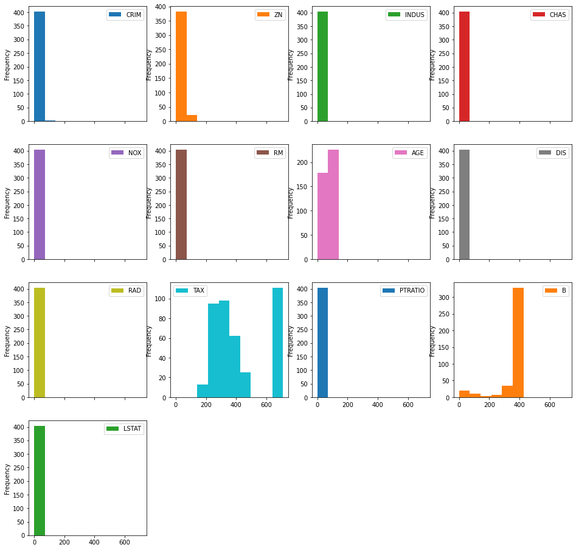

```python
# Histograms for each attribute
df_features_train.plot(kind='hist', subplots=True, layout=(display_rows, display_columns))
plt.show()
```

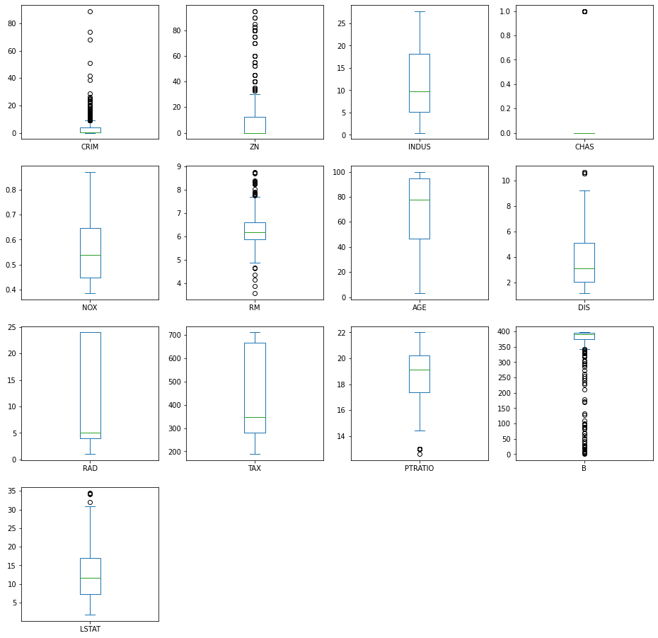

```python
# Box and Whisker plot for each attribute
df_features_train.plot(kind='box', subplots=True, layout=(display_rows, display_columns))
plt.show()
```

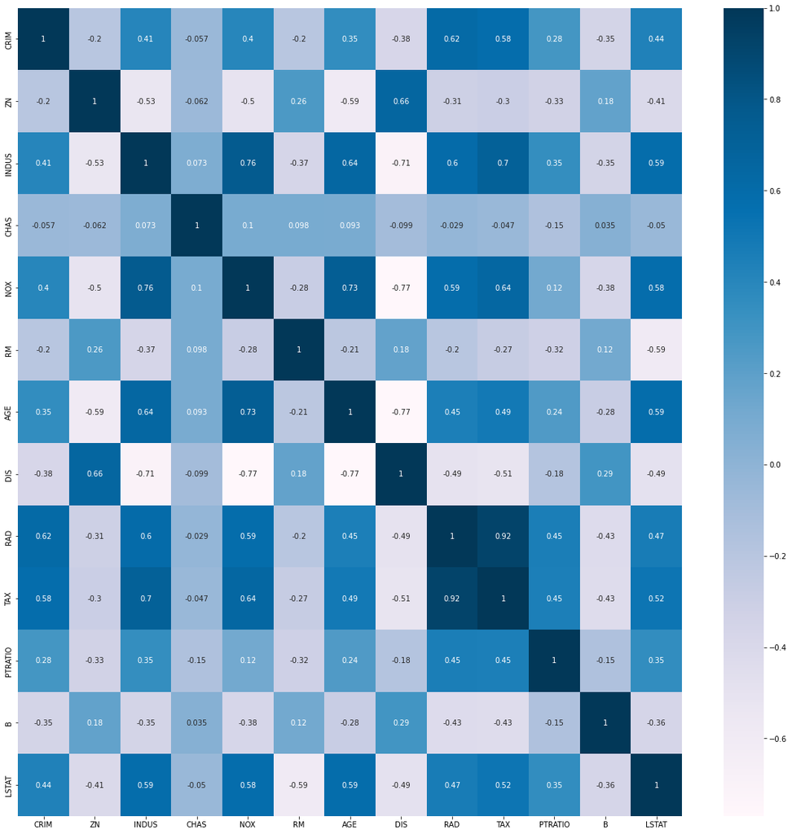

```python
# Correlation matrix
fig = plt.figure(figsize=(20, 20))
correlations = df_features_train.corr(method='pearson')
sns.heatmap(correlations, annot=True, cmap=plt.cm.PuBu)
plt.show()
```

```python
if NOTIFY_STATUS: status_notify("Task 2 - Summarize and Visualize Data completed! " + datetime.now().strftime('%a %B %d, %Y %I:%M:%S %p'))
```

## Task 3 - Pre-process Data

```python
if NOTIFY_STATUS: status_notify("Task 3 - Pre-process Data has begun! " + datetime.now().strftime('%a %B %d, %Y %I:%M:%S %p'))
```

### 3.a) Feature Scaling and Data Pre-Processing

```python
# Compose pipeline for the numerical and categorical features (Block #1 of 2)
numeric_columns = df_features_train.select_dtypes(include=['int64','float64']).columns
numeric_transformer = Pipeline(steps=[
    ('imputer', impute.SimpleImputer(strategy="constant", fill_value=0)),
    ('scaler', preprocessing.MinMaxScaler())
])
categorical_columns = df_features_train.select_dtypes(include=['object','bool','category']).columns
categorical_transformer = Pipeline(steps=[
    ('imputer', impute.SimpleImputer(strategy='constant', fill_value='UKNOWN')),
    ('onehot', preprocessing.OneHotEncoder(sparse=False, handle_unknown='ignore'))
])

print("Number of numerical columns:", len(numeric_columns))
print("Number of categorical columns:", len(categorical_columns))
print("Total number of columns in the feature dataframe:", df_features_train.shape[1])
```

```
Number of numerical columns: 13
Number of categorical columns: 0
Total number of columns in the feature dataframe: 13
```

```python
# Compose pipeline for the numerical and categorical features (Block #2 of 2)
preprocessor = compose.ColumnTransformer(transformers=[
    ('num', numeric_transformer, numeric_columns),
    ('cat', categorical_transformer, categorical_columns)
])

# Display the shapes of the training dataset for final inspection
array_features_train = preprocessor.fit_transform(df_features_train)
print("Transformed features from df_features_train.shape: {} to array_features_train.shape: {}".format(df_features_train.shape, array_features_train.shape))
```

```
Transformed features from df_features_train.shape: (404, 13) to array_features_train.shape: (404, 13)
```

### 3.b) Training Data Balancing

```python
# Not applicable for this iteration of the project
```

```python
# Perform SMOTE transformation on the training data (Block #1 of 2)

# X_train_imbal = X_train_df.values
# y_train_imbal = y_train_df.values.ravel()
# print("X_train_imbal.shape: {} y_train_imbal.shape: {}".format(X_train_imbal.shape, y_train_imbal.shape))
```

```python
# Perform SMOTE transformation on the training data (Block #2 of 2)

# print ('Original class distribution - 1: {} | 0: {}'.format((y_train_imbal==1).sum(), (y_train_imbal==0).sum()))
# sm = SMOTE(random_state=RNG_SEED, sampling_strategy=1.0)
# X_trainSmote, y_trainSmote = sm.fit_sample(X_train_imbal, y_train_imbal)
# print ('Resampled class distribution - 1: {} | 0: {}'.format((y_train==1).sum(), (y_train==0).sum()))
```

### 3.c) Display the Final Datasets for Model-Building

```python
# Finalize the training dataset for the modeling activities
# array_features_train = df_features_train.to_numpy()
array_target_train = df_target_train.ravel()
print("array_features_train.shape: {} array_target_train.shape: {}".format(array_features_train.shape, array_target_train.shape))
```

```
array_features_train.shape: (404, 13) array_target_train.shape: (404,)
```

```python
if NOTIFY_STATUS: status_notify("Task 3 - Pre-process Data completed! " + datetime.now().strftime('%a %B %d, %Y %I:%M:%S %p'))
```

## Task 4 - Train and Tune Models

```python
if NOTIFY_STATUS: status_notify("Task 4 - Train and Tune Models has begun! " + datetime.now().strftime('%a %B %d, %Y %I:%M:%S %p'))
```

```python
start_time_module = datetime.now()
reset_random()
auto_model = ak.StructuredDataRegressor(loss=DEFAULT_LOSS,
                                        metrics=DEFAULT_METRICS,
                                        max_trials=MAX_TRIALS,
                                        objective=keras_tuner.Objective("val_rmse", direction="min"),
                                        seed=RNG_SEED)
auto_model.fit(x=array_features_train,
               y=array_target_train,
               epochs=MAX_EPOCHS,
               validation_split=VAL_SET_RATIO,
               batch_size=BATCH_SIZE,
               verbose=1)
print('Total time for model fitting:', (datetime.now() - start_time_module))
```

```
Trial 50 Complete [00h 00m 20s]
val_rmse: 3.414729118347168

Best val_rmse So Far: 3.3068666458129883
Total elapsed time: 00h 17m 32s
INFO:tensorflow:Oracle triggered exit
```

```
2022-01-05 20:30:47.632985: W tensorflow/python/util/util.cc:348] Sets are not currently considered sequences, but this may change in the future, so consider avoiding using them.
```

```
INFO:tensorflow:Assets written to: ./structured_data_regressor/best_model/assets
Total time for model fitting: 0:17:39.587728
```

```python
if NOTIFY_STATUS: status_notify("Task 4 - Train and Tune Models completed! " + datetime.now().strftime('%a %B %d, %Y %I:%M:%S %p'))
```

## Task 5 - Finalize Model and Make Predictions

```python
if NOTIFY_STATUS: status_notify("Task 5 - Finalize Model and Make Predictions has begun! " + datetime.now().strftime('%a %B %d, %Y %I:%M:%S %p'))
```

### 5.a) Train the Final Model

```python
final_model = auto_model.export_model()
final_model.summary()
```

```
Model: "model"
_________________________________________________________________
Layer (type)                 Output Shape              Param #
=================================================================
input_1 (InputLayer)         [(None, 13)]              0
_________________________________________________________________
multi_category_encoding (Mul (None, 13)                0
_________________________________________________________________
normalization (Normalization (None, 13)                27
_________________________________________________________________
dense (Dense)                (None, 64)                896
_________________________________________________________________
batch_normalization (BatchNo (None, 64)                256
_________________________________________________________________
re_lu (ReLU)                 (None, 64)                0
_________________________________________________________________
dense_1 (Dense)              (None, 32)                2080
_________________________________________________________________
batch_normalization_1 (Batch (None, 32)                128
_________________________________________________________________
re_lu_1 (ReLU)               (None, 32)                0
_________________________________________________________________
dense_2 (Dense)              (None, 16)                528
_________________________________________________________________
batch_normalization_2 (Batch (None, 16)                64
_________________________________________________________________
re_lu_2 (ReLU)               (None, 16)                0
_________________________________________________________________
regression_head_1 (Dense)    (None, 1)                 17
=================================================================
Total params: 3,996
Trainable params: 3,745
Non-trainable params: 251
_________________________________________________________________
```

### 5.b) Load Test Dataset and Make Predictions

```python
# Finalize the test dataset for the testing activities
array_features_test = preprocessor.transform(df_features_test)
array_target_test = df_target_test.ravel()
print("array_features_test.shape: {} array_target_test.shape: {}".format(array_features_test.shape, array_target_test.shape))
```

```
array_features_test.shape: (102, 13) array_target_test.shape: (102,)
```

```python
# Make batched predictions
test_predictions = final_model.predict(array_features_test)
print(test_predictions)
```

```
[[23.849216 ]
 [39.41089  ]
 [21.06629  ]
 [23.514269 ]
 [19.967566 ]
 [21.105955 ]
 [31.198343 ]
 [24.324547 ]
 [25.544868 ]
 [14.438307 ]
 [25.80786  ]
 [22.942179 ]
 [18.4941   ]
 [20.574446 ]
 [23.920237 ]
 [11.547381 ]
 [13.6856   ]
 [19.870451 ]
 [22.90826  ]
 [25.925722 ]
 [27.244087 ]
 [36.139908 ]
 [19.830956 ]
 [22.95836  ]
 [30.941    ]
 [14.609779 ]
 [19.532475 ]
 [15.117886 ]
 [20.467016 ]
 [19.655905 ]
 [23.874914 ]
 [27.628271 ]
 [18.41489  ]
 [11.638778 ]
 [25.880888 ]
 [48.297432 ]
 [18.630507 ]
 [22.414104 ]
 [27.17964  ]
 [18.499308 ]
```

[output cut: 47 more lines]

```
 [10.939587 ]
 [41.053917 ]
 [21.103243 ]
 [11.349373 ]
 [50.33967  ]
 [19.546267 ]
 [21.136753 ]
 [24.821596 ]
 [19.316324 ]
 [10.996533 ]
 [20.518154 ]
 [21.266504 ]
 [19.80873  ]
 [26.654593 ]
 [49.908695 ]]
```

```python
print('RMSE for the model is: ', math.sqrt(mean_squared_error(array_target_test, test_predictions)))
print('R2 for the model is: ', r2_score(array_target_test, test_predictions))
```

```
RMSE for the model is:  2.7424220427625903
R2 for the model is:  0.9038992786611684
```

```python
if NOTIFY_STATUS: status_notify("Task 5 - Finalize Model and Make Predictions completed! " + datetime.now().strftime('%a %B %d, %Y %I:%M:%S %p'))
```

```python
print ('Total time for the script:',(datetime.now() - START_TIME_SCRIPT))
```

```
Total time for the script: 0:17:45.692150
```